# HW3 Hsiu-Yuan Fan 002430643

## 1. Answer the following?

a) Write and explain about the Linear Regression and it's equation [3 pts]

Linear Regression can model the relation between features(independent variables) and target(dependent variable). The equation is y= B0+ B1*x.

b) Explain in detail about the loss function of linear regression, R2, Adjusted R2 used in the Linear Regression and what is the need for Adjusted R2? [12 pts]

When we use linear regression to predict the target(y'), we compare the predicted value(y') with real y and get y-y'. It is what loss mean in loss function. R2 can be used to explain if the result came from linear regression is reasonable. The eauation of R2 is SSR/SST, and SST = SSR(sum of square due to regression) + SSE(sum of square due to error). However, there is disadvantage of R2 which is when the number of independent variables increases, the R2 increases, but it is not correct. Therefore, the adjusted R2 came out. The equation of adjusted R2 is 1-(1-R2)(n-1/n-k-1).

c) Plot X vs Y in Scatter plot from data in Table 1 and comment on the relation of X vs Y using Covariance,Corelation. Please comment on Covariance and corelation values [5 Pts]

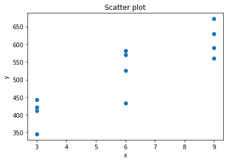

```python
import numpy as np
import pandas as pd
path = "C:\\Users\\Fan_2019\\Downloads\\Data Mining\\HW3\\HW3_Problem1.csv"
XY = pd.read_csv(path, sep=",")
import matplotlib.pyplot as plt
x = XY['x']
y = XY['y']
plt.scatter(x, y)
plt.title('Scatter plot')
plt.xlabel('x')
plt.ylabel('y')
plt.show()
```

```python
from numpy import cov
from scipy.stats import pearsonr
Covariance = cov(x,y)
print(covariance)
Correlation, _ = pearsonr(x, y)
print(Correlation)
```

[output not shown]

Covariance is a measure of the linear association between two variables. If the value is positive, it indicates a direct or increasing linear relationship. In this case, it is 2.26363636e+02. Correlation is similiar to covariance, but covariance only can tell the direction and correlation can tell both of direction and strength. In our case, the correlation is 0.87.

d) Perform Linear regression on the following data using Python? and print B0, B1 values in equation y= B0+ B1*x. Please write down what is your understanding from those values. [10 Pts]

```python
from sklearn.linear_model import LinearRegression
model = LinearRegression().fit(x.to_numpy().reshape(-1,1), y)
B0, B1 = model.intercept_, model.coef_
print('B0 = ', B0)
print('B1 = ', B1)

result = []
current = 0
while current < 12:
    result.append(B0 + B1*x[current])
    current+=1
```

```
B0 =  307.91666666666663
B1 =  [34.58333333]
```

```python
result
```

```
[array([515.41666667]),
 array([411.66666667]),
 array([515.41666667]),
 array([619.16666667]),
 array([411.66666667]),
 array([619.16666667]),
 array([515.41666667]),
 array([411.66666667]),
 array([619.16666667]),
 array([515.41666667]),
 array([411.66666667]),
 array([619.16666667])]
```

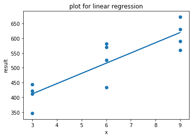

```python
x = XY['x']
plt.plot(x, result)
plt.scatter(x, y)
plt.title('plot for linear regression')
plt.xlabel('x')
plt.ylabel('result')
plt.show()
```

```python
def find_SSR(arr_r, arr_p):
    mean = np.average(arr_r)
    SSR = 0
    for i in arr_p:
        SSR += (i - mean)**2
    return SSR

def find_SSE(arr_r, arr_p):
    SSE = 0
    for i in range(len(arr_r)):
        SSE += (arr_r[i] - arr_p[i])**2
    return SSE
```

e) What are different evaluation metrics available for predicting the performance of the Linear Regression? Evaluate all those methods on the given dataset in Table 1 and also please print out the accuracy, R2, Adjusted R2 [10 pts]

```python
SSR = find_SSR(y ,result)
SSE = find_SSE(y ,result)
SST = SSR + SSE
R2 = SSR/SST
print('R2 = ',R2)
k = 1
adjusted_R2 = 1 - (1-R2)*((len(y)-1)/(len(y)-k-1))
print('adjusted_R2 = ',adjusted_R2)

#1. Mean Absolute Error (MAE)
#2. Mean Squared Error (MSE)
#3. Root Mean Squared Error (RMSE)

from sklearn import metrics

# calculate MAE, MSE, RMSE
MAE = metrics.mean_absolute_error(x, y)
print('MAE = ',MAE)
MSE = metrics.mean_squared_error(x, y)
print('MSE = ',MSE)
RMSE = np.sqrt(metrics.mean_squared_error(x, y))
print('RMSE = ',RMSE)
```

```
R2 =  [0.76357848]
adjusted_R2 =  [0.73993633]
MAE =  509.4166666666667
MSE =  268494.25
RMSE =  518.164307917865
```

MSE is too big, so it is not a good loss function, but it is easier to find a stable solution comparing to MAE. On the other hand, MAE is useful to deal with outlier because it is not so sensitive outlier.

f) Print ANOVA (Analysis of Variance) table and Parameter Estimates for the given data and explain your understanding.[See hints and explanation for what I am looking for] [10 pts]

```python
# from sklearn import svm
# from sklearn.datasets import samples_generator
# from sklearn.feature_selection import SelectKBest, f_regression
# from sklearn.pipeline import make_pipeline
# from sklearn.model_selection import train_test_split
# from sklearn.metrics import classification_report
# x = x.to_numpy().reshape(-1,1)
# anova_filter = SelectKBest(f_regression, k=1)
# clf = svm.LinearSVC()
# anova_svm = make_pipeline(anova_filter, clf)
# anova_svm.fit(x, y)
# y_pred = anova_svm.predict(x)
# print(classification_report(y, y_pred))
# coef = anova_svm[:-1].inverse_transform(anova_svm['linearsvc'].coef_)
# print(coef)

# from statsmodels.formula.api import ols
# results = ols('y ~ x', data=XY).fit()
# results.summary()
```

```python
import statsmodels.api as sm
# model = sm.OLS(result, B0+B1*x)
# results = model.fit()
# results.params
# results.summary()
from statsmodels.formula.api import ols
results = ols('y ~ x', data=XY).fit()
results.summary()
```

OLS Regression Results

| Dep. Variable: | y | R-squared: | 0.764 |
| --- | --- | --- | --- |
| Model: | OLS | Adj. R-squared: | 0.740 |
| Method: | Least Squares | F-statistic: | 32.30 |
| Date: | Sun, 13 Oct 2019 | Prob (F-statistic): | 0.000203 |
| Time: | 22:38:53 | Log-Likelihood: | -63.264 |
| No. Observations: | 12 | AIC: | 130.5 |
| Df Residuals: | 10 | BIC: | 131.5 |
| Df Model: | 1 |  |  |
| Covariance Type: | nonrobust |  |  |

|  | coef | std err | t | P>\|t\| | [0.025 | 0.975] |
| --- | --- | --- | --- | --- | --- | --- |
| Intercept | 307.9167 | 39.437 | 7.808 | 0.000 | 220.045 | 395.789 |
| x | 34.5833 | 6.085 | 5.683 | 0.000 | 21.024 | 48.142 |

| Omnibus: | 1.245 | Durbin-Watson: | 2.333 |
| --- | --- | --- | --- |
| Prob(Omnibus): | 0.537 | Jarque-Bera (JB): | 0.854 |
| Skew: | -0.341 | Prob(JB): | 0.652 |
| Kurtosis: | 1.885 | Cond. No. | 17.5 |

Warnings:  
[1] Standard Errors assume that the covariance matrix of the errors is correctly specified.

```python
results = ols('result ~ y', data=XY).fit()
results.summary()
```

OLS Regression Results

| Dep. Variable: | result | R-squared: | 0.764 |
| --- | --- | --- | --- |
| Model: | OLS | Adj. R-squared: | 0.740 |
| Method: | Least Squares | F-statistic: | 32.30 |
| Date: | Sun, 13 Oct 2019 | Prob (F-statistic): | 0.000203 |
| Time: | 22:38:54 | Log-Likelihood: | -61.645 |
| No. Observations: | 12 | AIC: | 127.3 |
| Df Residuals: | 10 | BIC: | 128.3 |
| Df Model: | 1 |  |  |
| Covariance Type: | nonrobust |  |  |

|  | coef | std err | t | P>\|t\| | [0.025 | 0.975] |
| --- | --- | --- | --- | --- | --- | --- |
| Intercept | 121.8556 | 70.466 | 1.729 | 0.114 | -35.152 | 278.863 |
| y | 0.7636 | 0.134 | 5.683 | 0.000 | 0.464 | 1.063 |

| Omnibus: | 2.133 | Durbin-Watson: | 2.522 |
| --- | --- | --- | --- |
| Prob(Omnibus): | 0.344 | Jarque-Bera (JB): | 1.121 |
| Skew: | 0.405 | Prob(JB): | 0.571 |
| Kurtosis: | 1.740 | Cond. No. | 2.84e+03 |

Warnings:  
[1] Standard Errors assume that the covariance matrix of the errors is correctly specified.  
[2] The condition number is large, 2.84e+03. This might indicate that there are  
strong multicollinearity or other numerical problems.

1. Answer the following [30 Pts]

a) What is Conditional probability, Marginal probability and Joint probability? Write their mathematical formulas and give one example each. [5 pts]

In a sample space, there are two event, A and B. Conditional probability means when A happened, what is the probability of B? For example,P(B|A). Marginal probability means only a single event happened such as what the probability of A or probability of B. For example, P(A) or P(B). Joint probability means what is the probability of A happened and B happened. For example, P(A)^P(B).

b) Explain what is Baye's rule with the formula and what is prior, posterior, likelihood and marginal probability in the Baye's rule. [10 pts]

The formula of Baye's rule is P(A|B) = P(B|A)*P(A)/P(B). P(A|B) is the posterior; P(B|A) is the likeihood; P(A) is prior; P(B) is marginal probability. This formula describes a probability which means when event B happened, what is the probability A?

Reference: https://en.wikipedia.org/wiki/Bayes%27_theorem#Simple_form

c) What is Naive Bayes algorithm and how is related or derived or inspired from Bayes rule? [5 pts]

In Naive Bayes algorithm, we will consider the likelihood like P(B|A) in question b. The B in P(B|A) can have multiple events like P(B0|A)*P(B1|A)*P(B2|A)....Then, it times the probability of P(A) which means target. Then, it devides the probability of P(B) which means the probability of specific features. Finally, we can tell in this condition if the target be true of false.

Reference:https://www.analyticsvidhya.com/blog/2017/09/naive-bayes-explained/

d) Perfom Naive Bayes algorithm on the below dataset in python in which you can classify wheather a Red Domestic SUV is stolen or not as shown in 2.2. [10 pts]

```python
path = "C:\\Users\\Fan_2019\\Downloads\\Data Mining\\HW3\\HW3_Problem2.csv"
NB = pd.read_csv(path)
NB
```

|  | Color | Type | Origin | Stolen? |
| --- | --- | --- | --- | --- |
| 0 | Red | Sports | Domestic | Yes |
| 1 | Red | Sports | Domestic | No |
| 2 | Red | Sports | Domestic | Yes |
| 3 | Yellow | Sports | Domestic | No |
| 4 | Yellow | Sports | Imported | Yes |
| 5 | Yellow | SUV | Imported | No |
| 6 | Yellow | SUV | Imported | Yes |
| 7 | Yellow | SUV | Domestic | No |
| 8 | Red | SUV | Imported | No |
| 9 | Red | Sports | Imported | Yes |

```python
current = 0
P_R_Y = 0
P_S_Y = 0
P_D_Y = 0
P_R = 0
P_S = 0
P_D = 0
P_Y = 0

while current < len(NB):
    if NB['Color'][current] == 'Red':
        P_R+=1
    if NB['Type'][current] == 'SUV':
        P_S+=1
    if NB['Origin'][current] == 'Domestic':
        P_D+=1
    if NB['Stolen?'][current] == 'Yes':
        P_Y+=1
        if NB['Color'][current] == 'Red':
            P_R_Y+=1
        if NB['Type'][current] == 'SUV':
            P_S_Y+=1
        if NB['Origin'][current] == 'Domestic':
            P_D_Y+=1
    current +=1


P_R_Y/=P_Y
P_S_Y/=P_Y
P_D_Y/=P_Y
P_R/=len(NB)
P_S/=len(NB)
P_D/=len(NB)
P_Y/=len(NB)

P_Y_RSD = (P_R_Y*P_S_Y*P_D_Y*P_Y/(P_R*P_S*P_D))
print('A red domestic car has',P_Y_RSD,'be stolen.')
```

```
A red domestic car has 0.24 be stolen.
```

```python
current = 0
P_R_N = 0
P_S_N = 0
P_D_N = 0
P_R = 0
P_S = 0
P_D = 0
P_N = 0

while current < len(NB):
    if NB['Color'][current] == 'Red':
        P_R+=1
    if NB['Type'][current] == 'SUV':
        P_S+=1
    if NB['Origin'][current] == 'Domestic':
        P_D+=1
    if NB['Stolen?'][current] == 'No':
        P_N+=1
        if NB['Color'][current] == 'Red':
            P_R_N+=1
        if NB['Type'][current] == 'SUV':
            P_S_N+=1
        if NB['Origin'][current] == 'Domestic':
            P_D_N+=1
    current +=1


P_R_N/=P_N
P_S_N/=P_N
P_D_N/=P_N
P_R/=len(NB)
P_S/=len(NB)
P_D/=len(NB)
P_N/=len(NB)

P_N_RSD = (P_R_N*P_S_N*P_D_N*P_N/(P_R*P_S*P_D))
print('A red domestic car has',P_N_RSD,'not be stolen.')
```

```
A red domestic car has 0.7199999999999999 not be stolen.
```

Therefore, the car has less chance to be stolen.